# Pacific Salmon SAR & SAS Estimator

- Show All Code
- Hide All Code
- View Source

Author

Kris Warner & Matt Siskey

## Setup

This script uses WDFW hatchery coded wire tag (CWT) release data and return data to fit program-specific smolt-adult return (SAR) models for Pacific salmon. However, if the user is instead interested in calculating return-per-release (i.e., not just returns for smolts), there is a “smolt” switch in the YAML header where setting ‘false’ will allow this.

Release and return data are categorized by treatments imposed related to release size, release stage, release location, and are uniquely identified by coded-wire-tag codes. SAR time series are then fit to generalized additive models to summarize trends, identify any potentially significant treatments. The first chunk below loads libraries, sets directories, and sources any functions required for the analysis. Future work will add:

- SAS rule making
- rTMB function to fill in missing return data
- Forecasting SAR
- Age-specific analyses
- Additional treatment structure for releases (e.g., volitional vs. forced, bisease-based, etc.)

```r
##############################
### Clear workspace & load libraries
# rm(list=ls())

# First-time rmisr install
# options(download.file.method = "wininet")
# devtools::install_github("MattCallahan-NOAA/rmisr", force=TRUE)

# Load packages, several aren't used in this workflow
pacman::p_load(rmisr, httr, magrittr, dplyr, purrr, stringr, tidyverse, knitr, kableExtra, ggplot2, plotly,
               RColorBrewer, jsonlite, janitor, keyring, mgcv, here, lubridate, tidygam, ggeffects)

# Supply API key through keyring to access RMIS server & maintain credential security
token <- key_get("rmis_api")

##############################
### Set up drives & controls
my_drive    <-paste0("C:/Users/sism1477/OneDrive - Washington State Executive Branch Agencies/")
share_drive <-paste0(my_drive,"DFW-Team FP Westside Hatchery MandE - R/")
proj_drive  <-paste0(share_drive,"psalmon_sar_sas/")
`%nin%`     <-negate(`%in%`) # create an exclude operator
source(paste0(proj_drive,"functions/functions.R",sep="")) #Source functions for use below
```

## Pull data & format

This chunk pulls CWT-based release, and recovery data from the Pacific States Marine Fisheries Commission’s (PSMFC) Regional Marking Information System (RMIS) database for the species and hatchery stock set by the user at the top of this script. Smolt-adult return (SAR) is calculated as the proportion of released fish that return to the hatchery location code designated. The fish released in any brood year will not all return to the rack, and those fish that do return to the rack will not all return the same year. Once the window for a brood year’s return has finished (6 years post-release), the SAR can be calculated.

To ensure all data employed in SAR calculations are smolt-release data, the script categorizes releases by stage using a mixture of information reported in the literature and RMIS data queried by the user. Quinn (2018) reports length-at-smolt (mm) by species in Table 15.1, which summarizes data from 218 published and unpublished reports. For Chinook, size-at-smolt is reported as a range of sizes starting at 60 mm. We use these reported values to inform a release stage designation, where the avg_length and avg_weight fields queried from RMIS by the user are fit to an exponential model and the model fit is used to predict weight-at-smolt. This weight-at-smolt is then used to classify release stages, currently implemented as “smolt” if they are larger than the threshold size calculated or “fry_parr” if smaller than it. Given the query-specific nature of this analysis, if program- or system-specific data on size-at-smolt were collected in the future, these data could be used directly to inform release_stage classifications.

Notes:

- Data filtering
  - Release data used excludes untagged release groups (i.e., tag_code_or_release_id begins with “!”)
  - Recovery data only include CWT-tagged fish
- Release calculation: cwt_1st_mark_count + cwt_2nd_mark_count
- Returns calculation: aggregate returns across tag_code or rearing treatment of interest
- User can specify to calculate SAR or RPR via a ‘smolt’ switch in the YAML header
  - Figures and tables will still report this as SAR currently
  - Work is ongoing to treat figure generation conditionally to correctly display SAR or RPR
- Avg_weight to fpp conversion:
  - avg_weight of 1 –> 454 fpp
  - avg_weight of 40 –> 12 fpp
  - avg_weight of 60 –> 8 fpp

```r
ruleset <-read.csv(paste0(proj_drive,"data/hatchery_program_ruleset.csv",sep=""))

### [LOCATION]
# loc_all <-get_location(token = token)
# rect <-loc_all |>
#   filter(location_type == 2) #|>
#   rename(recovery_location_name = name,
#      recovery_description = description,
#      recovery_location_code = location_code) |>
#   select(-c(id, format_version, record_code))


### [RELEASES] Pull in RMIS release data
### hatchery of interest location codes, found on the hatt data frame
hatcheries <-unique(filter(ruleset, system == params$system & loc_col == "hatchery_location_code")$loc_code)
# hatcheries <-"3F42001^^260002^H02"
rel_h <-list()

for(h in 1:length(hatcheries)){
  rel_h[[h]] <-rmisr::get_release(token = token,
                        species = params$sp,
                        # release_location_code = params$release_location_code)
                        hatchery_location_code = hatcheries[h])
}
names(rel_h) <-hatcheries
rel_df <-map_df(rel_h, ~as.data.frame(.))


### Assign release stage based on length-at-smolt and length-weight relationship
len_wt_df <-rel_df %>% drop_na(avg_length)
len_wt_df <-len_wt_df[order(len_wt_df$avg_length), ]
len_wt_fit <-lm(log(avg_weight) ~ avg_length, data=len_wt_df)
# summary(len_wt_fit)

if(params$sp==1){smolt_mm <-60} # chinook
if(params$sp==2){smolt_mm <-105} # coho
if(params$sp==3){smolt_mm <-200} # steelhead
if(params$sp==4){smolt_mm <-80} # sockeye
if(params$sp==5){smolt_mm <-40} # chum
if(params$sp==6){smolt_mm <-32} # pink
if(params$sp==8){smolt_mm <-190} # cutthroat

# len_wt_pred <-predict(len_wt_fit, newdata = data.frame(avg_length=smolt_mm))

len_wt_coefs <- coef(len_wt_fit)
a <- as.numeric(exp(len_wt_coefs[1]))  # 'a' is the initial value
r <- as.numeric(len_wt_coefs[2])       # 'r' is the growth/decay rate
len_wt_pred <- a * exp(r * 60)


rel_dat <-rel_df %>%
  mutate(release_stage_assigned = case_when(
      avg_weight > len_wt_pred ~ "smolt",
      # avg_weight >= 5 ~ "parr",
      avg_weight >= 0 ~ "fry_parr"
    )
  )

cols_to_fix <- c("cwt_1st_mark_count", "cwt_2nd_mark_count", "non_cwt_1st_mark_count", "non_cwt_2nd_mark_count")
rel_dat[cols_to_fix][is.na(rel_dat[cols_to_fix])] <- 0
rel_dat$event_released <-rel_dat$cwt_1st_mark_count +
                         rel_dat$cwt_2nd_mark_count
rel_dat$release_stage_assigned <-as.factor(rel_dat$release_stage_assigned)

rel_agg <-rel_dat %>% filter(!grepl("!",tag_code_or_release_id)) %>%
                      mutate(first_release_date = make_date(first_release_date_year, first_release_date_month, first_release_date_day)) %>%
                      mutate(jday = yday(first_release_date)) %>%
                      aggregate(event_released~species+brood_year+run+release_location_code+hatchery_location_code+stock_location_code+
                                               tag_code_or_release_id+first_release_date_year+first_release_date_month+first_release_date_day+
                                               first_release_date+jday+avg_weight+avg_length+release_stage_assigned,
                                data=., FUN=sum) %>%
                      rename(tag_code = tag_code_or_release_id)

if(params$yr_trim=="TRUE"){rel_agg <-filter(rel_agg, brood_year %in% params$yr_window)}


##############################
# [RETURNS] Pull in WDFW FishBooks return data
# use the tag codes from the release query to grab recoveries; pull capped at 500k records
rel_agg_cwt <-unique(rel_agg$tag_code)
rec_cwt <-list()

# Sys.time()
# test_rec <-get_recovery(token = token, tag_code = rel_agg_cwt[[15]], species = params$sp)
# Sys.time()

for(t in 1:length(rel_agg_cwt)){
  rec_cwt[[t]] <-get_recovery(token = token, tag_code = rel_agg_cwt[[t]], species = params$sp)
}

names(rec_cwt) <-rel_agg_cwt
rec_cwt_df <-map_df(rec_cwt, ~as.data.frame(.))


### this is the step where we distinguish btw sar & sas (recovery_location_code)
rec_agg <-rec_cwt_df %>%  mutate(recovery_date = make_date(recovery_date_year, recovery_date_month, recovery_date_day)) %>%
                          mutate(jday = yday(recovery_date)) %>%
                          aggregate(number_cwt_estimated~species+recovery_date_year+recovery_date+jday+recovery_location_code+fishery+tag_code,
                                     data=., FUN=sum) %>%
                          filter(., recovery_location_code %in% hatcheries)

rec_join <-aggregate(number_cwt_estimated~species+recovery_date_year+tag_code, data=rec_agg, FUN=sum)
rec_join_age <-left_join(rec_join,rel_agg[,c("brood_year","tag_code")], by = "tag_code")
rec_join_age$age <-rec_join_age$recovery_date_year-rec_join_age$brood_year
rec_join <-filter(rec_join_age, age >= 3)

########################## Join Release & Return Data for SAR ##########################
sar_df <-left_join(rel_agg, rec_join[,c("tag_code","number_cwt_estimated","recovery_date_year")], by = "tag_code") %>%
         mutate(avg_weight = ifelse(avg_weight < 5, round(avg_weight),round(avg_weight, digits = -1))) %>%
         aggregate(cbind(event_released,number_cwt_estimated)~species+brood_year+run+release_location_code+hatchery_location_code+
                                                              first_release_date_month+jday+avg_weight+release_stage_assigned,
                   data=., FUN=sum)
sar_df$sar <-sar_df$number_cwt_estimated/sar_df$event_released
if(params$smolt==TRUE){sar_df <-filter(sar_df,release_stage_assigned=="smolt")}


####################################
# set plotting theme
theme_set(theme_minimal())

### length-weight relationship of unfiltered data
len_wt <- ggplot(len_wt_df, aes(x=avg_length, y=avg_weight, group=as.factor(first_release_date_month), color=as.factor(first_release_date_month))) +
            # geom_line(aes(x = avg_length, y = prediction*100,group=first_release_date_month), linewidth=1) +
            geom_point(pch=21)+
            facet_wrap(.~run, ncol=1)+
            labs(x="Mean Length (mm)", y="Mean Weight (g)", color="Release Month")
ggplotly(len_wt)
```

[interactive chart not shown]

Figure 1: Length-weight relationship used to determine weight-at-smolt via reported lenght-at-smolt (Quinn, 2018). Facets are split by run, where 1 = spring and 3 = fall.

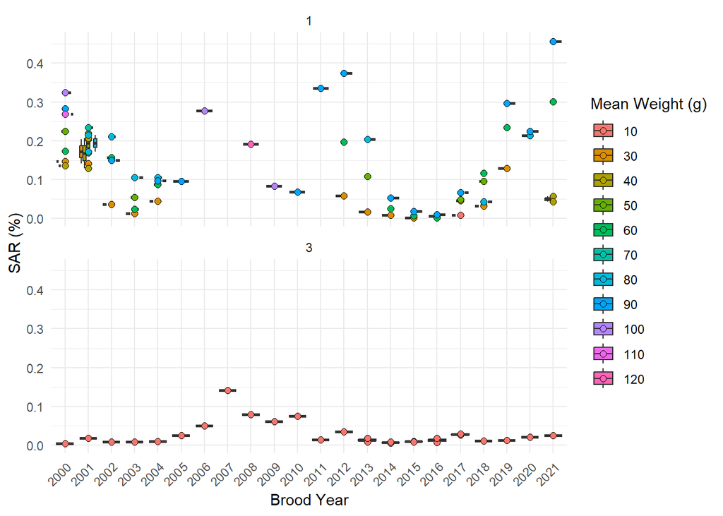

Figure 2: Smolt-adult return calculated across brood year released and mean weight-at-release groups. Facets are split by run, where 1 = spring and 3 = fall.

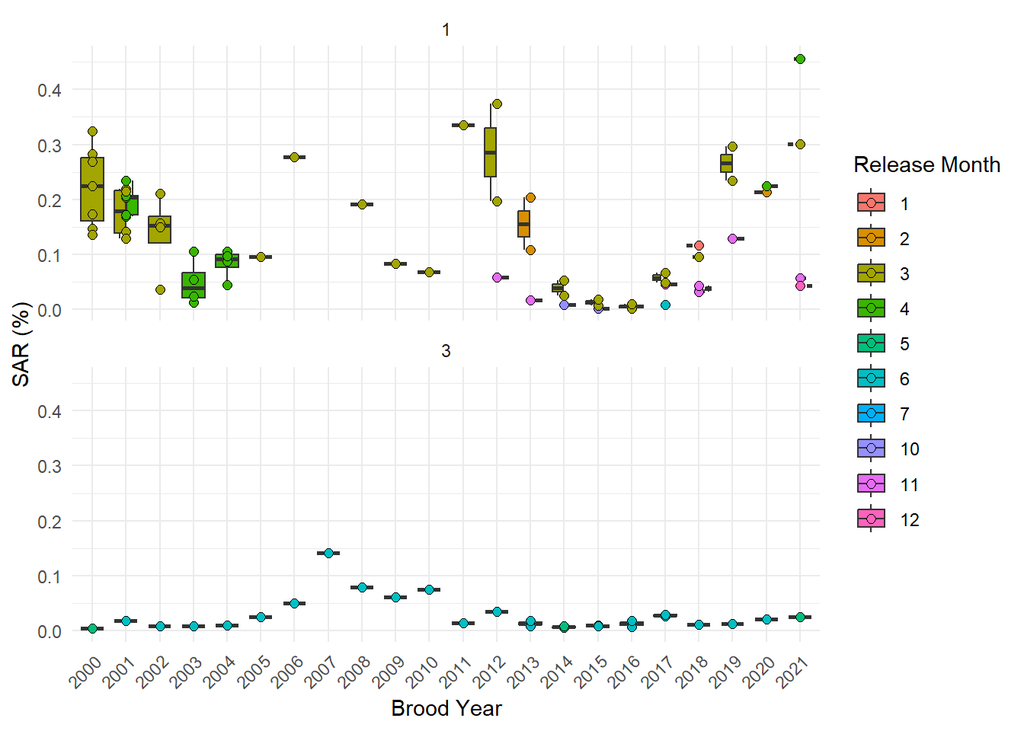

Figure 3: Smolt-adult return calculated across brood year released and mean month-at-release groups. Facets are split by run, where 1 = spring and 3 = fall.

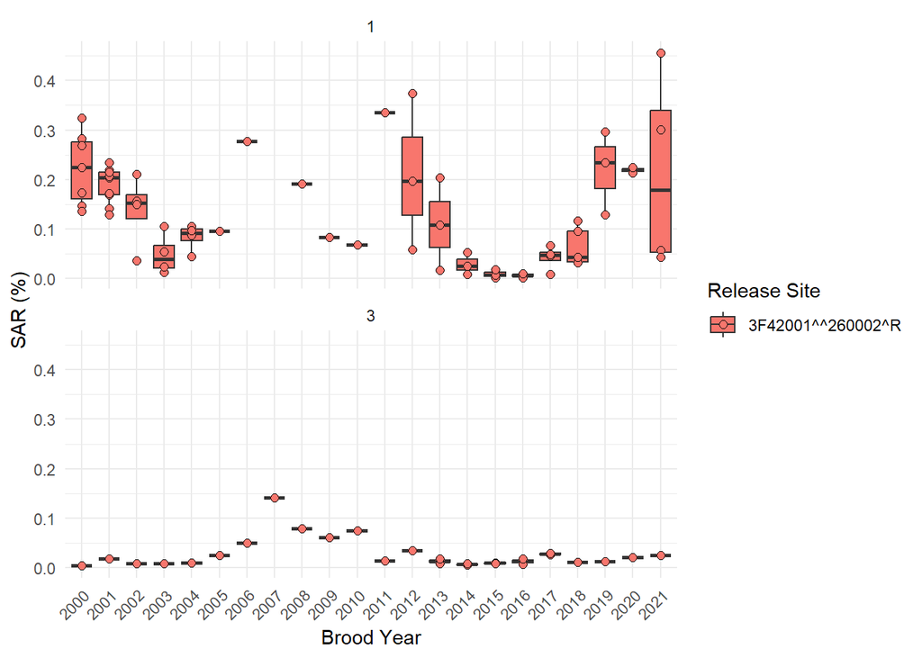

Figure 4: Smolt-adult return calculated across brood year released and release site groups. Facets are split by run, where 1 = spring and 3 = fall.

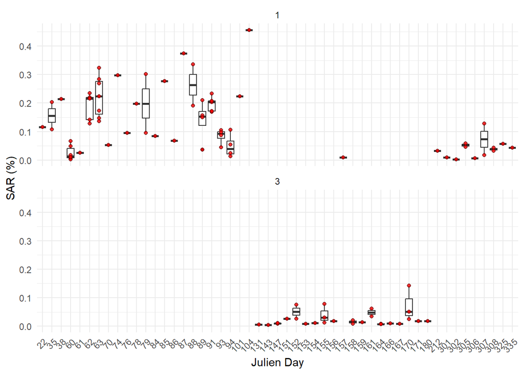

Figure 5: Smolt-adult return calculated across julien day released. Facets are split by run, where 1 = spring and 3 = fall.

```r
# ggplot(len_wt_df, aes(x=avg_length, y=avg_weight, group=as.factor(first_release_date_month), color=as.factor(first_release_date_month))) +
#   geom_point(aes(group=first_release_date_month)) +
#   geom_line(aes(x = avg_length, y = prediction,group=first_release_date_month), linewidth=1) +
#   # geom_ribbon(aes(ymin = lci,ymax = uci,group=first_release_date_month,color = as.factor(first_release_date_month)),alpha = 0.1) +
#   # facet_wrap(.~avg_weight, ncol=1)+
#   # theme_minimal() +
#   # labs(x = "Brood Year", y = "Predicted SAR (%)", color="Release Month") +
#   # scale_x_continuous(breaks=seq(min(sar_pred$brood_year),max(sar_pred$brood_year),1))+
#   # scale_y_log10(breaks = scales::breaks_pretty()) +
#   # scale_y_continuous(trans = "log",
#   #                    breaks = scales::breaks_pretty()) +
#   theme(legend.position = "none")#+
# plot(len_wt_df$avg_weight,len_wt_df$prediction)

### sar by brood year & mean wt
ggplot(data=sar_df,aes(x=as.factor(brood_year),y=sar*100, fill=as.factor(avg_weight)))+
    geom_boxplot()+
    geom_point(pch=21,size=2)+
    facet_wrap(.~run, ncol=1)+
    labs(x = "Brood Year", y = "SAR (%)", fill = "Mean Weight (g)")+
    # scale_x_continuous(limits=c(min(sar_df$brood_year),max(sar_df$brood_year)), breaks=seq(min(sar_df$brood_year),max(sar_df$brood_year),1))+
    theme(axis.text.x = element_text(angle = 45, hjust = 1)) # Angle x-axis labels for readability
    # theme(axis.text = element_text(size = 15)) +
    # theme(strip.text = element_text(size = 15)) +
    # theme(axis.title = element_text(size = 15))

### sar by brood year & release month
ggplot(data=sar_df,aes(x=as.factor(brood_year),y=sar*100, fill=as.factor(first_release_date_month)))+
    geom_boxplot()+
    geom_point(pch=21,size=2)+
    facet_wrap(.~run, ncol=1)+
    labs(x = "Brood Year", y = "SAR (%)", fill = "Release Month")+
    # scale_x_continuous(limits=c(min(sar_df$brood_year),max(sar_df$brood_year)), breaks=seq(min(sar_df$brood_year),max(sar_df$brood_year),1))+
    theme(axis.text.x = element_text(angle = 45, hjust = 1)) # Angle x-axis labels for readability
    # theme(axis.text = element_text(size = 15)) +
    # theme(strip.text = element_text(size = 15)) +
    # theme(axis.title = element_text(size = 15))

### sar by release location
# ggplot(data=sar_df,aes(x=as.factor(brood_year),y=sar, fill=as.factor(first_release_date_month)))+
ggplot(data=sar_df,aes(x=as.factor(brood_year),y=sar*100, fill=as.factor(release_location_code)))+
    # geom_boxplot(data=sar_df,aes(x=release_location_code,y=sar, group=release_location_code))+
    geom_boxplot()+
    geom_point(pch=21,size=2)+
    facet_wrap(.~run, ncol=1)+
    labs(x = "Brood Year", y = "SAR (%)", fill = "Release Site")+
    theme(axis.text.x = element_text(angle = 45, hjust = 1)) # Angle x-axis labels for readability
    # theme(axis.text = element_text(size = 15)) +
    # theme(strip.text = element_text(size = 15)) +
    # theme(axis.title = element_text(size = 15))

### sar by release timing (jday)
ggplot(data=sar_df,aes(x=as.factor(jday),y=sar*100))+
    # geom_hdr() +
    # geom_point(shape = 21)+
    geom_boxplot()+
    # geom_density_2d_filled(alpha = 0.8) +
    geom_point(alpha = 0.8,pch=21,fill="red") + # Optional: shows raw data points
    labs(x = "Julien Day", y = "SAR (%)", fill = "Release Site")+
    facet_wrap(.~run, ncol=1)+
    theme(axis.text.x = element_text(angle = 45, hjust = 1))+ # Angle x-axis labels for readability
    # theme(axis.text = element_text(size = 15)) +
    # theme(strip.text = element_text(size = 15)) +
    # theme(axis.title = element_text(size = 15)) +
    theme(legend.position = "none")
```

```r
sar_df[,c("species","brood_year","first_release_date_month","jday","avg_weight","event_released","sar")]%>%
  rename("month" = first_release_date_month) %>%
  arrange(brood_year, month,avg_weight) %>%
  select(-brood_year)%>%
  kbl(row.names = NA)%>%
  kable_classic(position="left",full_width = F, html_font = "Cambria")%>%
  # kable_material_dark() %>%
  kable_styling(bootstrap_options = c("condensed"))%>%
  pack_rows(index = table(sar_df$brood_year))
```

Table 1: Smolt-adult return calculated across brood years, mean weight-at-release, and time at release.

| species | month | jday | avg_weight | event_released | sar |
| --- | --- | --- | --- | --- | --- |
| **2000** |  |  |  |  |  |
| 1 | 3 | 63 | 30 | 757160 | 0.0014733 |
| 1 | 3 | 63 | 40 | 189724 | 0.0013563 |
| 1 | 3 | 63 | 50 | 636404 | 0.0022394 |
| 1 | 3 | 63 | 60 | 836824 | 0.0017369 |
| 1 | 3 | 63 | 90 | 188116 | 0.0028337 |
| 1 | 3 | 63 | 100 | 378844 | 0.0032404 |
| 1 | 3 | 63 | 110 | 376104 | 0.0026854 |
| 1 | 5 | 143 | 10 | 800496 | 0.0000469 |
| **2001** |  |  |  |  |  |
| 1 | 3 | 62 | 30 | 87808 | 0.0014139 |
| 1 | 3 | 62 | 40 | 90196 | 0.0012865 |
| 1 | 3 | 62 | 50 | 176128 | 0.0021907 |
| 1 | 3 | 62 | 80 | 159969 | 0.0021549 |
| 1 | 4 | 91 | 30 | 154747 | 0.0020347 |
| 1 | 4 | 91 | 40 | 91928 | 0.0020706 |
| 1 | 4 | 91 | 50 | 240026 | 0.0016903 |
| 1 | 4 | 91 | 70 | 94840 | 0.0023386 |
| 1 | 4 | 91 | 80 | 167669 | 0.0017230 |
| 1 | 6 | 156 | 10 | 629196 | 0.0001788 |
| **2002** |  |  |  |  |  |
| 1 | 3 | 89 | 30 | 454556 | 0.0003637 |
| 1 | 3 | 89 | 60 | 379650 | 0.0015645 |
| 1 | 3 | 89 | 80 | 154062 | 0.0021030 |
| 1 | 3 | 89 | 90 | 258813 | 0.0014933 |
| 1 | 6 | 153 | 10 | 600402 | 0.0000859 |
| **2003** |  |  |  |  |  |
| 1 | 4 | 94 | 30 | 281158 | 0.0001330 |
| 1 | 4 | 94 | 50 | 272946 | 0.0005411 |
| 1 | 4 | 94 | 60 | 88844 | 0.0002383 |

[output cut: 86 more lines]

## Fit SAR Models

```r
################################################################################
# [FIT_DAT] Prepare datasets for model fitting
### Join Release & Return Data for SAR
sar_df <-left_join(rel_agg, rec_join[,c("tag_code","number_cwt_estimated")], by = "tag_code") %>%
         mutate(avg_weight = round(avg_weight, digits = -1)) %>%
         aggregate(cbind(event_released,number_cwt_estimated)~species+brood_year+run+release_location_code+hatchery_location_code+
                                                              first_release_date_month+jday+avg_weight+release_stage_assigned,
                   data=., FUN=sum)

sar_df$sar <-sar_df$number_cwt_estimated/sar_df$event_released

if(params$smolt==TRUE){sar_df <-filter(sar_df,release_stage_assigned=="smolt")}
sar_df$tags_lost <-sar_df$event_released - sar_df$number_cwt_estimated
write.csv(sar_df, paste0(proj_drive,"sar_df_",params$sp,"_",params$system,".csv"))

if(params$sp==1){sar_df <-filter(sar_df, run==params$run)}

k_by <-length(unique(sar_df$brood_year))
k_jday <-length(unique(sar_df$jday))
k_wt <-length(unique(sar_df$avg_weight))


# (Default) m = 2 penalizes the second derivative (squared curvature), leading to a "visually smooth" fit
# m = 1 penalizes the first derivative (slope), which can result in a more "piecewise" appearance
mod <-gam(cbind(round(number_cwt_estimated), round(tags_lost)) ~
              + s(brood_year, bs="ps", m=1, k=k_by)
              + s(jday, bs="cc", m=2, k=k_jday)
              + s(avg_weight, bs="ts", m=2, k=k_wt)
              + te(jday, brood_year, bs = c("cc", "ps")),
              family=quasibinomial(link="logit"), data=sar_df, method="REML",
              na.action = "na.fail",
              select=T)

print(summary(mod))
```

```
Family: quasibinomial
Link function: logit

Formula:
cbind(round(number_cwt_estimated), round(tags_lost)) ~ +s(brood_year,
    bs = "ps", m = 1, k = k_by) + s(jday, bs = "cc", m = 2, k = k_jday) +
    s(avg_weight, bs = "ts", m = 2, k = k_wt) + te(jday, brood_year,
    bs = c("cc", "ps"))

Parametric coefficients:
            Estimate Std. Error t value Pr(>|t|)
(Intercept) -6.98465    0.05553  -125.8   <2e-16 ***
---
Signif. codes:  0 '***' 0.001 '**' 0.01 '*' 0.05 '.' 0.1 ' ' 1

Approximate significance of smooth terms:
                        edf Ref.df     F  p-value
s(brood_year)       14.0914     20 7.535  < 2e-16 ***
s(jday)              2.1332     31 0.299 0.000397 ***
s(avg_weight)        0.9737     10 3.484 5.68e-07 ***
te(jday,brood_year)  1.7905     19 0.193 0.014832 *
---
Signif. codes:  0 '***' 0.001 '**' 0.01 '*' 0.05 '.' 0.1 ' ' 1

R-sq.(adj) =  0.874   Deviance explained = 90.2%
-REML = -233.68  Scale est. = 34.685    n = 67
```

```r
# print(mod)
# print(gam.check(mod))


# Make predictions without including "tag_code"
preds <-predict(mod, newdata = sar_df, type = "response", se.fit = T) |>
        as_tibble() |>
        rename(prediction = fit, pred_se = se.fit) |>
        mutate(lci = qnorm(0.025, prediction, pred_se),
               uci = qnorm(0.975, prediction, pred_se))#,
               # across(lci, ~ case_when(. < 0 ~ 0, .default = .)))

# add predictions
sar_pred <-sar_df |> bind_cols(preds)
```

## Plot Predicted SAR

Generate figures showing the results of the SAR calculations and the selected model fit, including marginal effects.

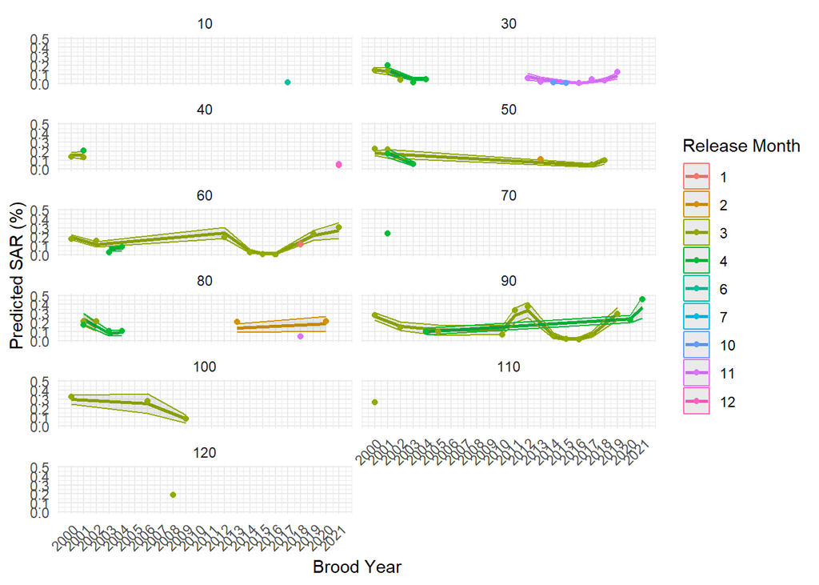

Figure 6: Predicted smolt-adult return generated from the model fit across brood years, mean weight release groups, and release month.

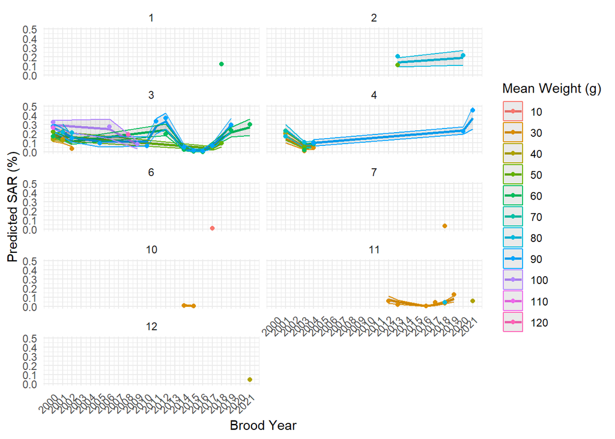

Figure 7: Predicted smolt-adult return generated from the model fit across brood years, mean weight release groups, and release month.

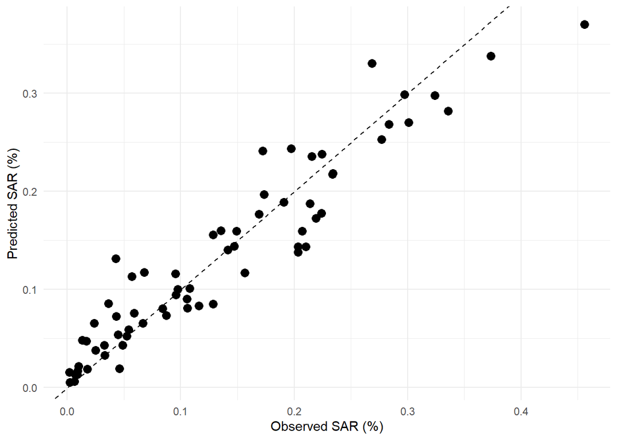

Figure 8: Observed vs. predicted smolt-adult return generated from the model fit.

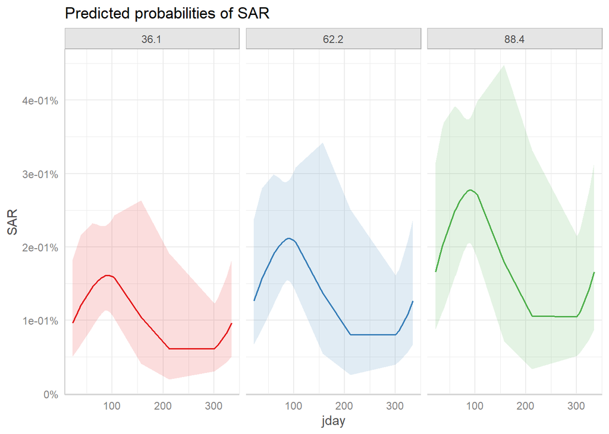

Figure 9: Marginal effects from the model fit showing how combined changes in mean weight at release and release timing (jday) affect smolt-adult-return.

```r
#create some plots
ggplot(sar_pred, aes(x=brood_year,y=sar*100,group=first_release_date_month,color=as.factor(first_release_date_month))) +
  geom_line(aes(x = brood_year, y = prediction*100,group=first_release_date_month), linewidth=1) +
  geom_ribbon(aes(ymin = lci*100,ymax = uci*100,group=first_release_date_month,color = as.factor(first_release_date_month)),alpha = 0.1) +
  geom_point(aes(group=first_release_date_month)) +
  facet_wrap(.~avg_weight, ncol=2)+
  # theme_minimal() +
  labs(x = "Brood Year", y = "Predicted SAR (%)", color="Release Month") +
  scale_x_continuous(breaks=seq(min(sar_pred$brood_year),max(sar_pred$brood_year),1))+
  # scale_y_log10(breaks = scales::breaks_pretty()) +
  # scale_y_continuous(trans = "log",
  #                    breaks = scales::breaks_pretty()) +
  theme(legend.position = "right")+
  theme(axis.text.x = element_text(angle = 45, hjust = 1)) # Angle x-axis labels for readability
  # theme(axis.text = element_text(size = 15)) +
  # theme(strip.text = element_text(size = 15)) +
  # theme(axis.title = element_text(size = 15))


ggplot(sar_pred, aes(x=brood_year,y=sar*100,group=avg_weight,color=as.factor(avg_weight))) +
  geom_line(aes(x = brood_year, y = prediction*100,group=avg_weight), linewidth=1) +
  geom_ribbon(aes(ymin = lci*100,ymax = uci*100,group=avg_weight,color = as.factor(avg_weight)),alpha = 0.1) +
  geom_point(aes(group=avg_weight)) +
  facet_wrap(.~first_release_date_month, ncol=2)+
  # theme_minimal() +
  labs(x = "Brood Year", y = "Predicted SAR (%)", color="Mean Weight (g)") +
  scale_x_continuous(breaks=seq(min(sar_pred$brood_year),max(sar_pred$brood_year),1))+
  # scale_y_log10(breaks = scales::breaks_pretty()) +
  # scale_y_continuous(trans = "log",
  #                    breaks = scales::breaks_pretty()) +
  theme(legend.position = "right")+
  theme(axis.text.x = element_text(angle = 45, hjust = 1)) # Angle x-axis labels for readability
  # theme(axis.text = element_text(size = 15)) +
  # theme(strip.text = element_text(size = 15)) +
  # theme(axis.title = element_text(size = 15))



sar_pred |>
  ggplot(aes(x = sar*100, y = prediction*100)) +
  geom_abline(linetype = 2) +
  geom_point(size = 3) +
  # scale_x_log10(breaks = scales::breaks_pretty()) +
  # scale_y_log10(breaks = scales::breaks_pretty()) +
  labs(x = "Observed SAR (%)", y = "Predicted SAR (%)")


margfx <-ggpredict(mod, terms = c("jday", "avg_weight"))
margfx_lab <-as_labeller(c("40" = "Mean Weight = 40",
                           "50" = "Mean Weight = 50",
                           "60" = "Mean Weight = 60"))
plot(margfx, facet = TRUE) +
  labs(x = "jday", y = "SAR", title = "Predicted probabilities of SAR")
```

## References

Quinn, T.P. 2018. The behavior and ecology of Pacific salmon and trout. Second Edition. University of Washington Press. ISBN 9780295743332.